# Tidy_data_othergrps_d4ato22

Fiona Burns/ Nick Isaac

Code adapted from script ‘02-tidy_othergrps_d4ato22.Rmd’, in notebook ‘rstudio-indeengto22’

This script:

- Brings together datasets of England-scale species time-series, barring birds
- It consolidates their formats to allow merging and selects a single time-series per species
- It removes data deficient species and does some data processing to allow the time-series to be combined into an abundance indicator

### Load libraries

Added renv to ensure all packages are saved with the project

### Load tidying functions

```r
source("/data/notebooks/rstudio-esaiukpsi26/tidy_functions.R")
```

# LOAD DATA

- Get lepidoptera, mammal, fw invertebrate, vascular plant and fish datasets into consistent format
- Process so have consistent column titles, scientific_name, common_name, index, year, country, index_sm
- Average across time-series where more than one present for a species

## LEPIDOPTERA

### UKBMS butterfly data

- We need to back transform index as currently on log10 scale

```r
bfly  <- read.csv("/data/species-timeseries/insects/ukbmscollatedindices2024.csv")

bfly1 <- bfly %>%
  mutate(index = 10 ^ bfly$COLLATED_INDEX ) %>%
  dplyr::rename(scientific_name = SPECIES, common_name = COMMON_NAME, year = YEAR,
         country = COUNTRY, sites = N_SITES,
         index.raw = COLLATED_INDEX, sp_no = SPECIES_CODE) %>%
  filter(country == "England") %>%
  select(-YEAR_RANK, -TIME_PERIOD, -country, -sp_no, -sites)

rm(bfly)
```

### Rothamsted moth data

- Assess how many psuedozeros (extremely low values and due to model can’t give zero as an answer)
- Convert psuedozeros to zeros.

```r
ris      <- read.csv("/data/species-timeseries/insects/Eng_ind_spp_yr_indices.csv") #read in time-series
ris_name <- read.csv("/data/species-timeseries/insects/spp_names.csv") #read in species names

ris <- ris %>%
  mutate(common_name     = as.character(ris_name$NAME_ENGLISH[match(ris$SPECIES,
                                                                    ris_name$SPECIES)]),
         scientific_name = as.character(ris_name$NAME[match(ris$SPECIES,
                                                            ris_name$SPECIES)])) %>%
  dplyr::rename(sp_no = SPECIES, index = INDEX, year = YEAR,
                lcl_unsm = LOW_INDEX, ucl_unsm = UPP_INDEX)
```

How many species in the dataset?

```r
length(unique(ris$scientific_name))
```

```
## [1] 448
```

448. This more than the 441 species that we expected to get. The RIS analyst told us that they had included all the species that passed his automatic checks. These are not a perfect match for the species that were put into Schedule 2 of The Environmental Targets (Biodiversity) (England) Regulations 2023. No need to worry about this now: in the next step we’ll filter the species list to match Schedule 2.

Now check the names

```r
temp <- unique(ris[,c("common_name", "scientific_name")])
sum(is.na(temp$common_name))
```

```
## [1] 1
```

```r
sum(is.na(temp$scientific_name))
```

```
## [1] 1
```

There is one species with no name. Which is it?

```r
head(ris[is.na(ris$common_name),])
```

```
##       sp_no year NSITES NSITES_POS        index     lcl_unsm     ucl_unsm NBOOT
## 14394   684 1968      2          1 8.647146e+00 1.728630e-09 1.005650e+02   869
## 14395   684 1969      2          1 8.761881e+00 1.728630e-09 1.005650e+02   869
## 14396   684 1970      4          0 4.716140e-08 4.181075e-09 7.024551e-07   966
## 14397   684 1971      4          0 3.716105e-08 5.649348e-13 5.048115e-07   985
## 14398   684 1972      4          0 3.647789e-08 5.496799e-13 5.048115e-07   985
## 14399   684 1973      5          0 3.095363e-08 2.081326e-13 2.250389e-07   997
##       common_name scientific_name
## 14394        <NA>            <NA>
## 14395        <NA>            <NA>
## 14396        <NA>            <NA>
## 14397        <NA>            <NA>
## 14398        <NA>            <NA>
## 14399        <NA>            <NA>
```

Species number 684 was not in previous dataset. It’s therefore not in Schedule 2 so we can ignore for now and drop.

Next we’ll look for small values. The RIS models are a little different to the UKBMS, even though they are structurally very similar. The main difference is that the index values actually relate to the raw data. Whereas in UKBMS the index values are all scaled to have a mean of 2 (which is log10(100)), the fitted values from RIS models are the expected number of moths on the whole scheme for that year This is really helpful for looking at small values, for there are some moths that genuinely small values, including zero counts. This reflects the much smaller number of sites on the RIS (~80) compared with UKBMS (>>1000), and the fact that some formerly common moths have experienced precipitous declines. So, we need to identify where there are zero counts and modify them, because they exert an undue weight on the final indicator line.

How many instances are there where the index is < 0.0001 and how many species are affected?

```r
table(cut(ris$index, breaks = c(0,0.0001,0.001,0.01,0.1,0.5,1,2,Inf)))
```

```
##
##     (0,0.0001] (0.0001,0.001]   (0.001,0.01]     (0.01,0.1]      (0.1,0.5]
##            679              2              0              1             18
##        (0.5,1]          (1,2]        (2,Inf]
##             32            151          24237
```

You can see that most values are higher than one. There is a small number where the fitted value lies between 0.1 and 1 individual. We can keep these: they will be unlikely to exert a big influence on the multispecies index. But we need to be worried about the 679 really small values. The reason to be concerned is that, when log-transformed, these tiny numbers will exert an undue weight on the fitted line.

NB when the estimate is in single figures the ci can span multiple orders of magnitude.

Let’s choose 0.001 as our cutoff (NB initially 0.0001 was used): the ten-fold increase captures just two extra species:year combinations. How many species are affected by these pseudozeros?

```r
pZ <- 0.001

pseudoZeros_byspp <- ris %>%
  dplyr::group_by(scientific_name) %>%
  dplyr::summarise(pseudoZeros = sum(index <= pZ)) %>%
  filter(pseudoZeros != 0)
nrow(pseudoZeros_byspp)
```

```
## [1] 123
```

123, which is 27% of species in the dataset. But recall the actual number of pseudozeros is tiny, just 679 out of more than 24,000 observations (2.8%).

Next, we want to know whether these pseudozeros are concentrated near the end of the timeseries

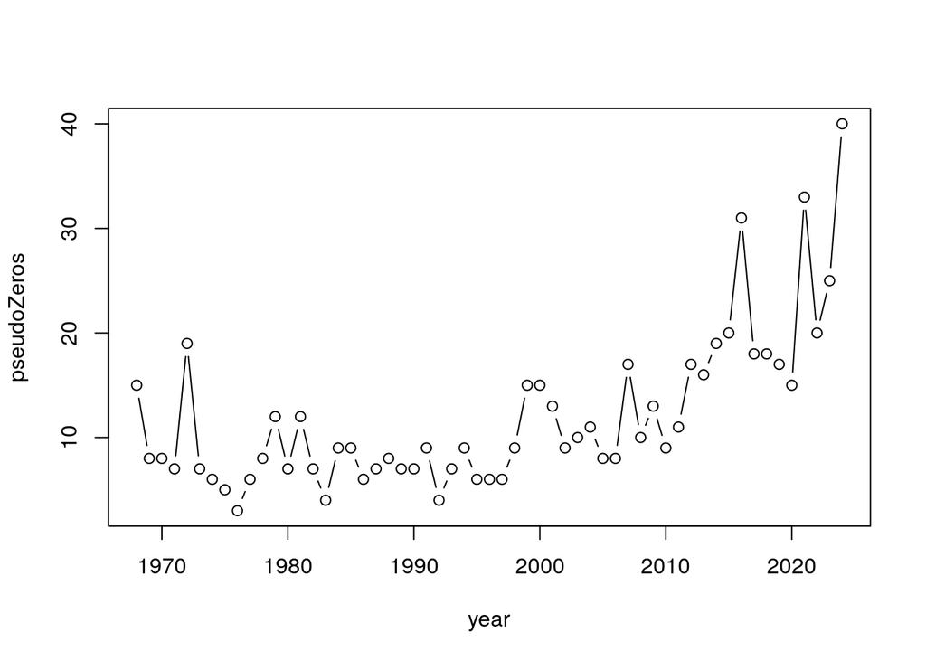

```r
pseudoZeros_byYr <- ris %>%
  group_by(year) %>%
  dplyr::summarise(pseudoZeros = sum(index <= pZ)) %>%
  filter(pseudoZeros != 0)
plot(pseudoZeros_byYr, type = "b")
```

There are three spikes, in 2016, 2021 and 2024 and there is an upward trend.

Potential development option: It would be useful to further investigate the way we treat zeros and these psuedozeros. It may be that adding 1% of the average across all index values for a species is too high for groups like moths where interannual variation can be considerable. Other work noted that the controlled psuedozeros were in some cases higher than non-zero counts, which warrants further investigation.

As noted above, these extremely low values in RIS should be treated as zeros. They occur when no moths have been recorded, but the model is on the log scale and therefore can’t “predict” an actual zero ( `log(0) = -Inf`). Having defined our threshold, `pZ`, above, we’ll set all these to be zero. At a later step, these will be converted to some other value.

```r
ris1 <- ris %>%
  filter(!is.na(scientific_name)) %>% #rm species with no name match
  mutate(index.raw = index) %>%
  mutate(index = ifelse(index < pZ, 0, index)) %>% #change extremely small values to zero
  select(-NBOOT, -NSITES, -NSITES_POS)
rm(ris, ris_name)
```

### BC priority moth monitoring dataset

- New data file doesn’t have scientific names, so load old data and match names first

```r
# Load the old file that contains scientific names
pri_m_lookup <- read.csv("/data/species-timeseries/insects/priority_moth_indices_to_2021_SM_scientific.names.csv") %>%
  rename(common_name = common.name, scientific_name = scientific.name) %>%
  mutate(
    common_name_lower = str_trim(str_to_lower(common_name)),  # Store lowercase for matching
    scientific_name_lower = str_trim(str_to_lower(scientific_name)),  # Store lowercase for matching
    scientific_name = str_trim(scientific_name)  # Keep original capitalization
  )

# Load and process pri_m1 dataset
pri_m1 <- read.csv("/data/species-timeseries/insects/scarce_moth_trim_indices_to_2023_filtered.csv") %>%
  rename(year = time, index = imputed, se = se_imp, common_name = Species) %>%
  select(-X) %>%
  mutate(
    common_name_lower    = str_trim(str_to_lower(common_name)),  # Store lowercase for matching
    original_common_name = common_name  # Retain original common name for output
  )

# First try to match using common_name (case-insensitive matching)
pri_m1 <- pri_m1 %>%
  mutate(scientific_name =
           pri_m_lookup$scientific_name[match(common_name_lower, pri_m_lookup$common_name_lower)]) %>%
# Find rows that still have NA in `scientific_name` (possible scientific names in `common_name` column)
  mutate(scientific_name = ifelse(
    is.na(scientific_name),
    pri_m_lookup$scientific_name[match(common_name_lower, pri_m_lookup$scientific_name_lower)],
    scientific_name
  )) %>%
# Keep only the required columns
  select(scientific_name, common_name, year, index, se) #nsite, time, imputed, se_imp,

# Check how many names matched
matched_names <- sum(!is.na(pri_m1$scientific_name))
total_names   <- nrow(pri_m1)
#281 matched names out of 305 total names

# Find and print unmatched names
unmatched_names <- pri_m1 %>%
  filter(is.na(scientific_name)) %>%
  select(common_name) %>%
  distinct()  # Remove duplicates
# Print summary
cat("Number of unmatched common names:", nrow(unmatched_names), "\n")
```

```
## Number of unmatched common names: 2
```

```r
# Print the unmatched names
print(unmatched_names)
```

```
##          common_name
## 1    Barberry Carpet
## 2 Fisher's Estuarine
```

```r
# From NBN Atlas - https://nbnatlas.org/
# Barberry carpet - Pareulype berberata
# Fisher's Estuarine - Gortyna borelii
pri_m1 <- pri_m1 %>%
  mutate(scientific_name = ifelse(common_name == "Barberry Carpet", "Pareulype berberata",
                                  ifelse(common_name  == "Fisher's Estuarine", "Gortyna borelii",
                                         as.character(scientific_name))))
rm(pri_m_lookup, unmatched_names)
summary(pri_m1$index)
```

```
##     Min.  1st Qu.   Median     Mean  3rd Qu.     Max.
##  0.04839  0.43900  0.91032  2.23978  1.48684 64.44444
```

```r
#are there are data deficient species?
pri_m1 %>%
  group_by(common_name) %>%
  summarise(min_yr = min(year[!is.na(index)]),
            max_yr = max(year[!is.na(index)])) %>%
  mutate(dur = max_yr - min_yr) %>%
  filter(dur < 10)
```

```
## # A tibble: 2 × 4
##   common_name        min_yr max_yr   dur
##   <chr>               <int>  <int> <int>
## 1 Fisher's Estuarine   2017   2022     5
## 2 Straw Belle          2016   2022     6
```

There are two species with less than ten years data

- One is new (in 2025) and so not on SI (Fisher’s Estuarine) (five years)
- One is on SI, but earlier data has been deemed too sparse to contribute - Straw Belle (six years)
- We could either retain the latter as it will get to the minimum of ten years, or exclude until that point. Taken latter approach.

## BUMBLEBEES

- Need to melt to df format
- Sort out names

Bombus lucorum and terrestris are named on Schedule 2 as a species group, but the data contains estimates for the two species individually as well as the group. For now we’ll proceed with the grouped data. - lucter is only the data that could not be split by species - All the lucter data are added to both single species datasets

Potential development option: We could consider alternative approaches, either taking an average of the B. lucorum and B terrestris time-series or including the terrestris and lucorum estimates in with the lucter data.

```r
bbees <- read.csv("/data/species-timeseries/insects/national year averages 2010-25 06012026.csv")

bumbles_to_include <- c("Bombus pascuorum", "Bombus lapidarius", "Bombus pratorum", "Bombus hypnorum",
                        "Bombus hortorum",  "Bombus lucorum", "Bombus terrestris", "Bombus lucter",
                        "Bombus vestalis",  "Bombus sylvestris", "Bombus campestris", "Bombus rupestris",
                        "Bombus humilis")

bbees1 <- bbees %>%
  pivot_longer(
    cols = -Year,
    names_to = "scientific_name",
    values_to = "index",
    values_drop_na = FALSE) %>%
  mutate(sd = ifelse(grepl("sd", scientific_name) == TRUE, "sd_unsm", "ind"),
         scientific_name = gsub(".sd", "", scientific_name)) %>%
  pivot_wider(names_from = sd, values_from = index) %>%
  filter(scientific_name != "Apis") %>% # remove honeybee index
  mutate(scientific_name = paste("Bombus", scientific_name)) %>%
  rename(year = Year,
         index = ind) %>%
  mutate(common_name = NA_character_) %>%
  filter(scientific_name %in% bumbles_to_include,
         year < 2025 ) #data is a year ahead, remove final year

rm(bbees, bumbles_to_include)
summary(bbees1$index)
```

```
##    Min. 1st Qu.  Median    Mean 3rd Qu.    Max.
## 0.01488 0.13461 0.48232 0.85674 1.52555 3.46296
```

The summary clarifies that all the values are positive numbers, so we can be confident they are on the abundance scale (not the log scale).

## MAMMALS

### BBS Mammals

```r
bh <-
  read.csv("/data/species-timeseries/mammals/bbs-mammal-index-for-eng_brown_hare.csv") %>%
  mutate(common_name = "Brown Hare")
rab <-
  read.csv("/data/species-timeseries/mammals/bbs-mammal-index-for-eng_rabbit.csv") %>%
  mutate(common_name = "Rabbit")
fox <-
  read.csv("/data/species-timeseries/mammals/bbs-mammal-index-for-eng_red_fox.csv") %>%
  mutate(common_name = "Red Fox")
fald <-
  read.csv("/data/species-timeseries/mammals/bbs-mammal-index-for-eng_fallow_deer.csv") %>%
  mutate(common_name = "Fallow Deer")
rowd <-
  read.csv("/data/species-timeseries/mammals/bbs-mammal-index-for-eng_roe_deer.csv") %>%
  mutate(common_name = "Roe Deer")

bbs_names <- read.csv("/data/species-timeseries/mammals/species_codes.csv")

bbs_mam <- bh %>%
  full_join(rab) %>%
  full_join(fox) %>%
  full_join(fald) %>%
  full_join(rowd) %>%
  left_join(bbs_names) %>%
  dplyr::rename(index = Unsmoothed, year = Year, index_sm = Smoothed,
         lcl_sm = Confidence.Interval..low., ucl_sm = Confidence.Interval..high.) %>%
  select(-species_code)
```

[output not shown]

```r
rm(bh, rab, fox, fald, rowd, bbs_names)
summary(bbs_mam$index)
```

```
##    Min. 1st Qu.  Median    Mean 3rd Qu.    Max.    NA's
##   27.81   81.47   97.02  113.62  140.99  566.22      10
```

### National Water Vole Monitoring Scheme

```r
wvol <-
  read.csv("/data/species-timeseries/mammals/wvoletrends_2024_FB.csv",
           skip = 5, nrows = 10)
# Read only rows 6-14 from a CSV file
wvol <- wvol %>%
  mutate(common_name = "Water Vole", scientific_name = "Arvicola amphibius")%>%
  rename(index_sm = smoothed_index, index = unsmoothed_fit,
         lcl_sm   = smoothed_lower, ucl_sm = smoothed_upper,
         lcl_unsm = unsmoothed_lower, ucl_unsm = unsmoothed_upper) %>%
  select(common_name, scientific_name, index, lcl_unsm, ucl_unsm, index_sm,
         year, lcl_sm, ucl_sm)
```

NB. time-series 10 years long

### Dormouse - NDMP

```r
dor  <- read_excel("/data/species-timeseries/mammals/2024 NDMP dataset.xlsx",
                   skip = 2)
head(dor)
```

```
## # A tibble: 6 × 14
##    Year Species        counts Sites `Mean count` estimate...6 s.e....7 lower...8
##   <dbl> <chr>           <dbl> <dbl>        <dbl>        <dbl>    <dbl>     <dbl>
## 1  1998 Hazel dormouse     42    42         5.36        121.      9.73     100.
## 2  1999 Hazel dormouse     51    51         4.82        110.      4.31     101.
## 3  2000 Hazel dormouse     79    79         4.38        100       0        100
## 4  2001 Hazel dormouse     79    79         3.20         90.9     3.11      85.7
## 5  2002 Hazel dormouse     89    89         4.21         83.9     5.08      75.3
## 6  2003 Hazel dormouse     97    97         3.05         78.2     6.12      67.6
## # ℹ 6 more variables: upper...9 <dbl>, estimate...10 <dbl>, s.e....11 <dbl>,
## #   lower...12 <dbl>, upper...13 <dbl>, `Data source` <chr>
```

```r
colnames(dor)<-c("year", "common_name", "counts", "sites", "mean_count",
                 "index_sm", "se_sm", "lcl_sm", "ucl_sm",
                 "index", "se_unsm", "lcl_unsm", "ucl_unsm",
                 "source")

dor1  <- dor %>%
  mutate(scientific_name = "Muscardinus avellanarius",
         common_name = "Dormouse")

rm(dor)
summary(dor1$index)
```

```
##    Min. 1st Qu.  Median    Mean 3rd Qu.    Max.
##   31.07   38.68   57.06   58.43   71.23  109.11
```

### NBMP data

- no common name, get from 2017 data
- remove roost survey from common and sop pip as known to be negatively biased, not used in C8
- In C8 and in previous iteration of this indicator we have only used data from 1998 across all species and surveys. We have asked BCT about this and they recommended using data from 1998 onward.

```r
bat      <- read.csv("/data/species-timeseries/mammals/Species trend indices and CIs.csv",
                     skip=1)
bat_name <- read.csv("/data/species-timeseries/mammals/NBMP_country_2017.csv")

bat1  <- bat %>%
  dplyr::rename(year = Year, scientific_name = Species, index_sm = `Smoothed.index`,
               se = SE, lcl_sm = `Lower.95..CI`, ucl_sm = `Upper.95..CI`) %>%
  filter(!(Survey == "Roost Count" & scientific_name == "Pipistrellus pipistrellus"|
           Survey == "Roost Count" & scientific_name == "Pipistrellus pygmaeus")) %>%
  filter(Geographical.scale == "England") %>% #filter to England sites
  filter(!year < 1998) %>%
  mutate(common_name = as.character(bat_name$Species[match(scientific_name, bat_name$scientific_name)])) %>%
  mutate(common_name = ifelse(scientific_name == "Myotis mystacinus/brandtii",
                              "Whiskered/Brandt's", as.character(common_name)))
rm(bat, bat_name)
```

#### Take average of multiple time-series per bat species

- Need to get average time series for bats with more than one survey available
- Averaging using standard geomean function, so time-series need to be rescaled
- Need to check time-series don’t have any missing values, beyond starting in different years
- Need to make sure that all time-series end in the same year.

Functions now in ‘tidying_functions.R’

- function to calculate geometric mean [geometric]
- function to calculate indicator, which requires a dataframe of species indices where each row is a species year combination [indFun1]
- function to rescale time-series relative to first value [rescale]

Which species have more than one survey per year?

```r
bat1 %>%
  group_by(scientific_name, Survey) %>%
  summarise(
      min_yr = min(year[!is.na(index_sm)]),
      max_yr = max(year[!is.na(index_sm)]),
      yrs    = length(index_sm[!is.na(index_sm)])) %>%
  ungroup() %>%
  mutate(dur = max_yr - min_yr) %>%
  mutate(missing = ifelse(yrs == (dur + 1), "N", "Y"))
```

```
## # A tibble: 16 × 7
##    scientific_name            Survey           min_yr max_yr   yrs   dur missing
##    <chr>                      <chr>             <int>  <int> <int> <int> <chr>
##  1 Eptesicus serotinus        Field Survey       1998   2024    27    26 N
##  2 Eptesicus serotinus        Roost Count        1998   2024    27    26 N
##  3 Myotis daubentonii         Hibernation Sur…   1998   2024    26    26 Y
##  4 Myotis daubentonii         Waterway Survey    1998   2024    27    26 N
##  5 Myotis mystacinus/brandtii Hibernation Sur…   1998   2024    26    26 Y
##  6 Myotis nattereri           Hibernation Sur…   1998   2024    26    26 Y
##  7 Myotis nattereri           Roost Count        2000   2024    25    24 N
##  8 Nyctalus noctula           Field Survey       1998   2024    27    26 N
##  9 Pipistrellus pipistrellus  Field Survey       1998   2024    27    26 N
## 10 Pipistrellus pygmaeus      Field Survey       1998   2024    27    26 N
## 11 Plecotus auritus           Hibernation Sur…   1998   2024    26    26 Y
## 12 Plecotus auritus           Roost Count        1998   2024    27    26 N
## 13 Rhinolophus ferrumequinum  Hibernation Sur…   1998   2024    26    26 Y
## 14 Rhinolophus ferrumequinum  Roost Count        1998   2024    27    26 N
## 15 Rhinolophus hipposideros   Hibernation Sur…   1998   2024    26    26 Y
## 16 Rhinolophus hipposideros   Roost Count        1998   2024    27    26 N
```

- Serotine, Daubentons, Natterers, Brown long-eared, GHS, LHS have more than one time-series
- When set start year to 1998, only Natterers has different start years
- All Hibernation Surveys and missing a data point, this is 2021

Processing required

- Expand to fill in missing spp/yr rows (‘expand’)
- Interpolate across missing values within ts (‘approx’)
- Rescale relative to first value (‘rescale’)

```r
bat2 <- bat1 %>%
  expand(nesting(scientific_name, common_name, Survey), year = full_seq(year, 1)) %>%
  left_join(bat1) %>%
  group_by(Survey, scientific_name) %>%
  mutate(index_sm_int = approx(year, index_sm, xout = year, method= "linear")$y) %>%
  mutate(index_sm = ifelse(is.na(index_sm) & Survey == "Hibernation Survey", index_sm_int, index_sm)) %>%
  ungroup() %>%
  select(-index_sm_int)
```

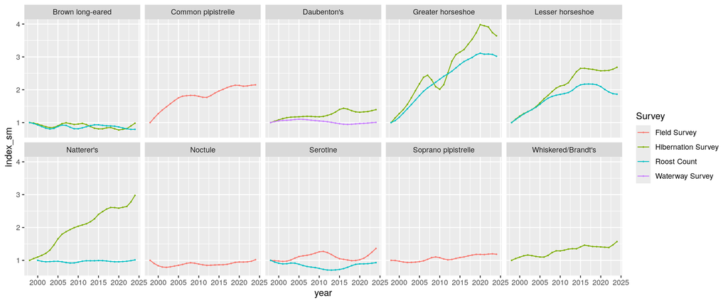

```r
# only works using ddply not piped
bat2 <- bat2 %>%
  ddply(.(Survey), rescale, ind_col = index_sm, Index_root = 1) %>%
  ungroup()

# check bat time series
ggplot(bat2, aes(x= year, y= index_sm, colour = Survey))+
   geom_line()+
  geom_point(size=.25)+
  facet_wrap(vars(common_name), nrow = 2)
```

Average bats with more than 1 survey

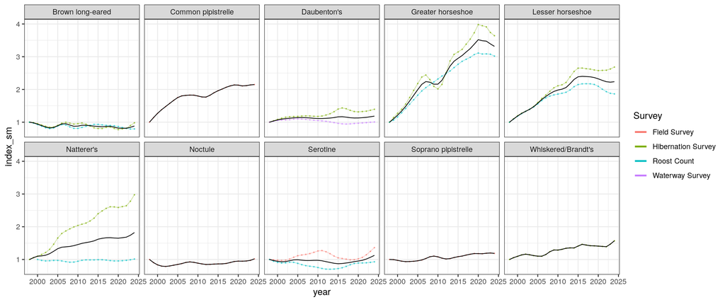

```r
bat3 <- ddply(bat2, .(scientific_name), indFun1, index_sm, grp_col = Survey) %>% #again, only works via ddply
  dplyr::mutate(common_name = bat2$common_name[match(scientific_name, bat2$scientific_name)],
                index = comp_index) %>% #only dataset without unsmoothed option, just duplicate smoothed version
  dplyr::rename(index_sm = comp_index)

#check averaging has worked
ggplot() +
  # bat2: all surveys
  geom_line(
    data = bat2,
    aes(x = year, y = index_sm, group = Survey, colour = Survey),
    linewidth = 0.4,
    alpha = 0.35
  ) +
  geom_point(
    data = bat2,
    aes(x = year, y = index_sm, colour = Survey),
    size = 0.25,
    alpha = 0.5
  ) +
  # bat3: averaged trend (one line per species)
  geom_line(
    data = bat3,
    aes(x = year, y = index_sm, group = 1),
    linewidth = 0.4,
    colour = "black"
  ) +
  facet_wrap(vars(common_name), nrow = 2) +
  guides(colour = guide_legend(override.aes = list(alpha = 1, linewidth = 1))) +
  theme_bw()
```

- all looks ok SM 18/02/26

Check no dups spp/yr

```r
a <- with(bat3, table(scientific_name, year))
table(a > 1)
```

```
##
## FALSE
##   270
```

Tidy up and summarise.

```r
rm(bat1, bat2)
summary(bat3$index)
```

```
##    Min. 1st Qu.  Median    Mean 3rd Qu.    Max.
##  0.7869  0.9641  1.1386  1.3792  1.6548  3.5203
```

## FRESHWATER INVERTEBRATES

These data are model outputs where the counts have been modelled on as `log10(x+1)`, so we need to back-transform them to predicted counts.

```r
Inverts25 <-
  read_excel("/data/species-timeseries/freshwater/ETI_235Inverts_update_to_2024.xlsx",
             skip = 1)

#check its a dataframe
Inverts25 <- as.data.frame(Inverts25)
#remove unneeded Taxon_codes
Inverts25 <- Inverts25[, -(1:2)]

fw_i1 <- Inverts25 %>%
  reshape::melt(id.vars = c("Taxon_name"), variable_name = "year" )%>%
  mutate(year = as.numeric(as.character(year)),
          index = (10 ^ value) - 1, #backtransform from log10(x+1) scale
          common_name = NA,
          Taxon_name = gsub(" sp.", " spp.", Taxon_name)) %>%
  #change `sp.` in Taxon to `spp.` to match species list
  mutate(Taxon_name = gsub("\\s*\\([^\\)]+\\)","", Taxon_name)) %>%
  #dataset has lots of subgenus names in brackets, doesn't match SI, remove
  rename(scientific_name = Taxon_name,
         index.raw = value)
```

check for values less than zero as cannot convert these to a log scale to create indicator. Treat as zeros

```r
fw_i1 %>%
  filter(index < 0) #5 instances where index is below zero on measurement scale, treat as zero
```

```
##      scientific_name year     index.raw         index common_name
## 1     Caenis pusilla 2020 -2.448868e-03 -5.622859e-03          NA
## 2    Sigara fossarum 2020 -6.666902e-04 -1.533933e-03          NA
## 3 Graptodytes pictus 2020 -6.457523e-04 -1.485795e-03          NA
## 4 Hydrobius fuscipes 2020 -1.880556e-04 -4.329203e-04          NA
## 5  Haliplus confinis 2024 -1.873356e-05 -4.313469e-05          NA
```

```r
fw_i1 <- fw_i1 %>%
   mutate(index = ifelse(index < 0, 0, index))

rm(Inverts25)
summary(fw_i1$index)
```

```
##     Min.  1st Qu.   Median     Mean  3rd Qu.     Max.
##  0.00000  0.01182  0.05360  0.39990  0.19546 26.55716
```

## FISH

These are Freshwater and coastal fish. These data have been modeled as a double square root transformation, i.e. the fourth root. So, to get back to the measurement scale we need to raise the data to the fourth power.

```r
fish25 <-
  as.data.frame(read_excel("/data/species-timeseries/freshwater/ETI_37Fish_update_to_2024.xlsx",
                           skip = 1))
#check column names
head(fish25)
```

```
##             Species  Common name ETI_SP_ID FW Sites TraC Sites       2000
## 1 Anguilla anguilla European eel       241        Y          Y 0.24375671
## 2 Sprattus sprattus        Sprat       571        Y          Y 0.09473763
## 3   Clupea harengus      Herring       531        Y          Y         NA
## 4     Barbus barbus       Barbel       151        Y       <NA> 0.19463022
## 5       Gobio gobio      Gudgeon       193        Y          Y 0.24729651
## 6       Tinca tinca        Tench       201        Y          Y 0.07183449
##         2001      2002       2003       2004       2005        2006       2007
## 1 0.21669561 0.2282078 0.21151579 0.19205945 0.19500231  0.19372341 0.17503527
## 2         NA 0.1242478 0.25030295 0.31580111 0.28370430  0.38938817 0.34756887
## 3         NA        NA         NA 0.02932474 0.07683633 -0.03838100 0.07005293
## 4 0.11610528 0.1174022 0.11775098 0.12946083 0.12091706  0.13028794 0.10779831
## 5 0.24615393 0.2214030 0.22344410 0.21211698 0.23671165  0.23221561 0.21671404
## 6 0.05137549 0.0522620 0.04784077 0.05828787 0.06454655  0.07532537 0.07871848
##         2008       2009       2010       2011       2012       2013       2014
```

[output cut: 20 more lines]

```r
#remove unneeded columns
fish25 <- fish25[, -(3:5)]

fish1 <- fish25 %>%
   as.data.frame() %>%
   reshape::melt(id.vars = c("Species","Common name"), variable_name = "year") %>%
   mutate(year = as.numeric(as.character(year))) %>%
   mutate(index  = value ^ 4) %>% #backtransform from double square root scale
   rename(common_name = "Common name",
         scientific_name = "Species",
         index.raw = value)

rm(fish25)
summary(fish1$index)
```

```
##    Min. 1st Qu.  Median    Mean 3rd Qu.    Max.    NA's
## 0.00000 0.00011 0.00079 0.00632 0.00519 0.13324      98
```

There are a few NAs: we know there was no survey in 2020 for any species (due to Covid) and some were also missing in 2021. Let’s plot the data to check:

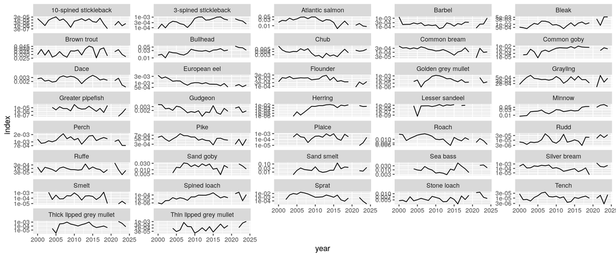

```r
ggplot(fish1, aes(x = year, y = index)) +
  geom_line()+
  scale_y_log10() +
  facet_wrap(vars(common_name), nrow=8, scales = "free_y")
```

Closer inspection reveals that the `index.raw` value for Herring in 2006 is actually negative. In 2026 this is also now the case for a few other species too (Lesser sandeel and Common goby)

```r
subset(fish1, index.raw < 0)
```

```
##            scientific_name    common_name year    index.raw        index
## 109 Pomatoschistus microps    Common goby 2002 -0.082725479 4.683356e-05
## 222     Ammodytes tobianus Lesser sandeel 2005 -0.003799498 2.084035e-10
## 225        Clupea harengus        Herring 2006 -0.038381002 2.170028e-06
```

This is a function of using data transformations rather than a GLM with link function. It’s clearly another case where no organisms were observed and the model is producing spurious values. For some reason, the `index` value is actually positive. We should also treat these as zeros.

convert the negative values in index.raw to zeros in the associated index column

```r
fish1 <- fish1 %>%
  mutate(index     = ifelse(index.raw < 0, 0, index))
```

## VASCULAR PLANTS

- This year, for the first time we have England level time-series rather than uk. The values are weighted means, although the column is not called that.

```r
npms <- read.csv("/data/species-timeseries/plants/allEnglandTrends_2015to2024_04092025.csv")

npms1 <- npms %>%
  mutate(index = 100 * mean,
         lcl_unsm = lo*100,
         ucl_unsm = hi*100,
         common_name = NA) %>%
  dplyr::rename(scientific_name = species,
                index.raw = mean, year=Year) %>%
  select(scientific_name, common_name, year, index, lcl_unsm, ucl_unsm, index.raw)

summary(npms1$index)
```

```
##     Min.  1st Qu.   Median     Mean  3rd Qu.     Max.
##  0.05861  0.85925  1.48871  2.10848  2.51033 21.82998
```

```r
rm(npms)
```

- all plant time-series are ten years long

No duplication between data sources so no need to filter to a single time-series per species at this stage

# AGGREGATE DATASETS

### Join datasets into a list

```r
lm_l <- list(bfly1, ris1, dor1,  pri_m1, bbs_mam,  wvol, bat3,  fish1, fw_i1, bbees1, npms1)
names(lm_l) <- c("ukbms", "ris", "ndmp", "prior_m", "bbs_m", "nwvmp", "nbmp", "fish", "fw_inv", "beewalks", "npms")
```

### Remove data deficient species

Functions now read in from ‘tidying_functions.Rmd’ script

- function to remove species with no data all, NAs or a comb of NAs and zeros [no_data]
- function to remove species years with no data [no_data_yr]
- function to remove species with a year range of less than ten years [rm_dpoor]

Run no data yr, no data, and rm_dpoor

```r
lm_l1 <- llply(lm_l, no_data_yr)
ldply(lm_l1, function(x) n_distinct(x$scientific_name));ldply(lm_l, function(x) n_distinct(x$scientific_name)) #none
```

```
##         .id  V1
## 1     ukbms  55
## 2       ris 447
## 3      ndmp   1
## 4   prior_m  17
## 5     bbs_m   5
## 6     nwvmp   1
## 7      nbmp  10
## 8      fish  37
## 9    fw_inv 235
## 10 beewalks  13
## 11     npms 329
```

```
##         .id  V1
## 1     ukbms  55
## 2       ris 447
## 3      ndmp   1
## 4   prior_m  17
## 5     bbs_m   5
## 6     nwvmp   1
## 7      nbmp  10
## 8      fish  37
## 9    fw_inv 235
## 10 beewalks  13
## 11     npms 329
```

```r
lm_l2 <- llply(lm_l1, no_data)
ldply(lm_l2, function(x) n_distinct(x$scientific_name));ldply(lm_l1, function(x) n_distinct(x$scientific_name)) #none
```

```
##         .id  V1
## 1     ukbms  55
## 2       ris 447
## 3      ndmp   1
## 4   prior_m  17
## 5     bbs_m   5
## 6     nwvmp   1
## 7      nbmp  10
## 8      fish  37
## 9    fw_inv 235
## 10 beewalks  13
## 11     npms 329
```

```
##         .id  V1
## 1     ukbms  55
## 2       ris 447
## 3      ndmp   1
## 4   prior_m  17
## 5     bbs_m   5
## 6     nwvmp   1
## 7      nbmp  10
## 8      fish  37
## 9    fw_inv 235
## 10 beewalks  13
## 11     npms 329
```

```r
lm_l3 <- lm_l2
lm_l3$prior_m <- rm_dpoor(lm_l3$prior_m)
ldply(lm_l3, function(x) n_distinct(x$scientific_name));ldply(lm_l2, function(x) n_distinct(x$scientific_name)) #none
```

```
##         .id  V1
## 1     ukbms  55
## 2       ris 447
## 3      ndmp   1
## 4   prior_m  15
## 5     bbs_m   5
## 6     nwvmp   1
## 7      nbmp  10
## 8      fish  37
## 9    fw_inv 235
## 10 beewalks  13
## 11     npms 329
```

```
##         .id  V1
## 1     ukbms  55
## 2       ris 447
## 3      ndmp   1
## 4   prior_m  17
## 5     bbs_m   5
## 6     nwvmp   1
## 7      nbmp  10
## 8      fish  37
## 9    fw_inv 235
## 10 beewalks  13
## 11     npms 329
```

```r
rm(lm_l1, lm_l, lm_l2)
```

- To date we have only run rm_dpoor on moths in order to retain water vole and vascular plants, which had fewer than ten years of data
- Now could run ‘rm_dpoor’ on everything as WV and VP have reached ten years, action to update this in 2027

# PROCESS DATA

For the species remaining make sure data are in the correct format to combine in a composite species index

The ‘tidying_rpd’ function produces a dataframe giving the number of species where:

- There are NAs at the start/within/at the end of species’ time-series
- There are zeros at the start/within/at the end of species’ time-series
- There are there missing rows in the time-series

### Tidying required

Run tidying required function across each dataset in list and save report

```r
lm_tr <- llply(lm_l3, tidying_rqd)
```

Save tidy report

```r
lm_tr1 <- ldply(lm_tr)
write.csv(lm_tr1[, c(1, 4, 2, 3)], file = "/data/tidy_data/intermediate_files/tidy_rpt_lepmam_engto24_120326.csv", row.names = FALSE)
```

### Tidying

The ‘tidy_d’ function allows user defined processing of datasets to:

- Add rows for missing species years
- Convert zeros at the start of time-series to NAs
- Where zeros are present within time-series add 1% of the average value of a species’ time-series to all elements of it.
- Use linear interpolation to fill in NAs within species’ time-series
- Hold final time-series values constant where they end before the final year of other species

#### Run tidying function across list of datasets

Here we are processing the datasets ready for the Freeman model. So we need to:

- Remove zeros at the start of time-series
- Add 1% of mean ts value to all elements where >=1 elements == 0

```r
lm_tidy <- list(0)
for(i in 1:length(lm_l3)) {
  lm_tidy[[i]] <- tidy_d(lm_l3[[i]], lm_tr[[i]], exp.g = "N", zero_st = "Y", zero_in = "Y")
}
names(lm_tidy) <- names(lm_l3)

lm_tidy1 <- ldply(lm_tidy) %>%
  mutate(group = ifelse(.id == "ris"| .id == "prior_m", "moths",
                        ifelse(.id == "ukbms", "butterflies",
                                ifelse(.id == "fish", "fish",
                                      ifelse(.id == "fw_inv", "fw invertebrates",
                                              ifelse(.id == "beewalks", "bumblebees",
                                                     ifelse(.id == "npms", "vascular plants",
                                          "mammals"))))))) %>%
  select(.id, group, scientific_name, common_name, year, index, se,sd_unsm, lcl_unsm, ucl_unsm,
         index_sm, se_sm, lcl_sm, ucl_sm, index_orig, index.raw, uk_spp) %>%
  mutate(across(scientific_name:common_name, ~ str_to_lower(.x)))
```

### Save compiled dataset

```r
write.csv(lm_tidy1, file = "/data/tidy_data/intermediate_files/lep_mam_vp_compile_engto24_120326.csv", row.names = FALSE)
```

# CHECKS

First check for duplicates

```
## # A tibble: 0 × 4
## # Groups:   group, scientific_name [0]
## # ℹ 4 variables: group <chr>, scientific_name <chr>, year <dbl>,
## #   instances <int>
```

There are none

Next, look for NAs.

```r
lm_tidy1 %>%
  group_by(group) %>%
  summarise(instances = n(), sciNameNA = sum(is.na(scientific_name)), commonNA = sum(is.na(common_name)),
            yearNA = sum(is.na(year)), indexNA = sum(is.na(index)))
```

```
## # A tibble: 7 × 6
##   group            instances sciNameNA commonNA yearNA indexNA
##   <chr>                <int>     <int>    <int>  <int>   <int>
## 1 bumblebees             195         0      195      0       0
## 2 butterflies           2563         0        0      0       0
## 3 fish                   888         0        0      0      61
## 4 fw invertebrates      2820         0     2820      0       0
## 5 mammals                457         0        0      0      10
## 6 moths                25355         0        0      0      76
## 7 vascular plants       3290         0     3290      0       0
```

We also know that not all of the datasets have common names. NAs for `index` are not unexpected: some were described above.

Number of species by group and survey

```r
ddply(lm_tidy1, .(group, .id), summarise, n_sp = n_distinct(scientific_name))
```

```
##               group      .id n_sp
## 1        bumblebees beewalks   13
## 2       butterflies    ukbms   55
## 3              fish     fish   37
## 4  fw invertebrates   fw_inv  235
## 5           mammals    bbs_m    5
## 6           mammals     nbmp   10
## 7           mammals     ndmp    1
## 8           mammals    nwvmp    1
## 9             moths  prior_m   15
## 10            moths      ris  447
## 11  vascular plants     npms  329
```